# Homework5

Sailesh Potturi

10/10/2022

## Decompose

- Data Set used - fdeaths

```r
library(fpp)
library(fpp2)
head(fdeaths)
```

```
##      Jan Feb Mar Apr May Jun
## 1974 901 689 827 677 522 406
```

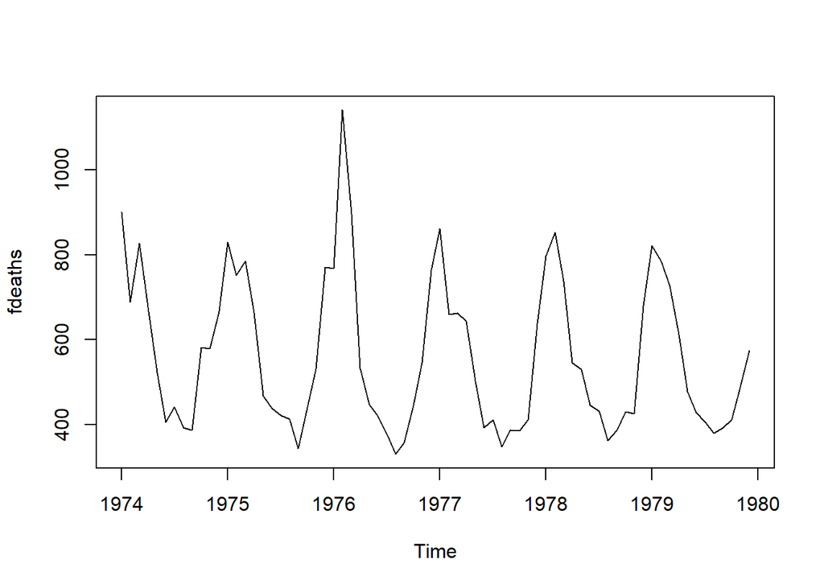

```r
plot(fdeaths)
```

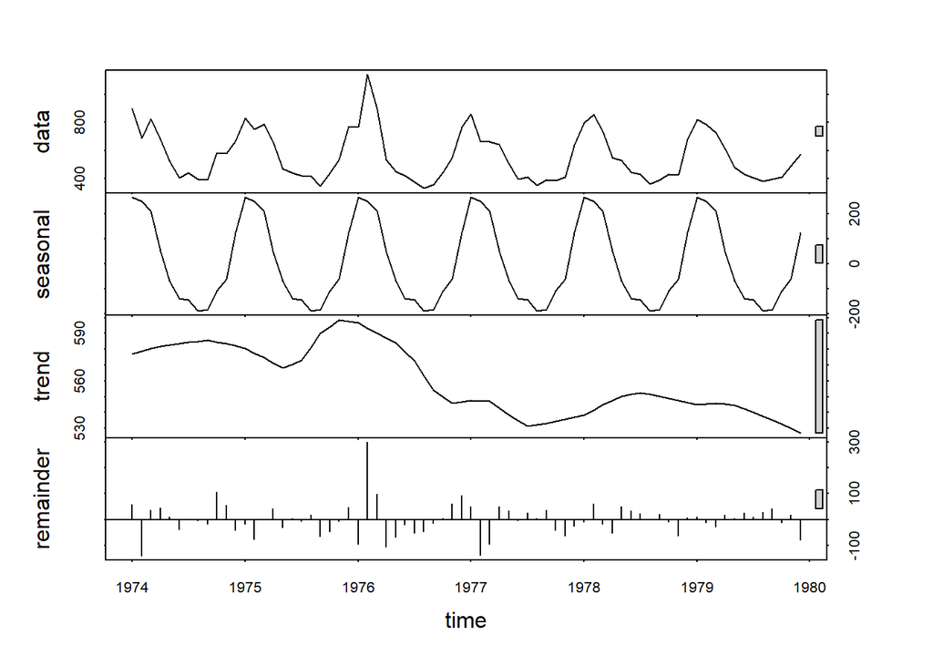

```r
stl_decomp <- stl(fdeaths,s.window ="periodic")
plot(stl_decomp)
```

```r
attributes(stl_decomp)
```

```
## $names
## [1] "time.series" "weights"     "call"        "win"         "deg"
## [6] "jump"        "inner"       "outer"
##
## $class
## [1] "stl"
```

- Decompose function is used to separate the the trend, seasonality and the irregularity in the data.
- From the plot above, we can see that there is a seasonality in the data and there is an downward trend.

```r
seasadj(stl_decomp)
```

```
##           Jan      Feb      Mar      Apr      May      Jun      Jul      Aug
## 1974 635.7325 439.6821 618.2986 627.3730 592.6141 544.7531 586.3922 581.6032
## 1975 564.7325 502.6821 576.2986 614.3730 537.6141 576.7531 566.3922 600.6032
## 1976 501.7325 891.6821 687.2986 482.3730 517.6141 558.7531 521.3922 518.6032
## 1977 596.7325 410.6821 454.2986 593.3730 572.6141 530.7531 556.3922 536.6032
## 1978 530.7325 603.6821 528.2986 496.3730 600.6141 584.7531 576.3922 550.6032
## 1979 555.7325 535.6821 518.2986 562.3730 548.6141 567.7531 550.3922 567.6032
##           Sep      Oct      Nov      Dec
## 1974 570.3142 691.5989 639.5502 541.0878
## 1975 526.3142 549.5989 592.5502 646.0878
## 1976 540.3142 554.5989 607.5502 639.0878
## 1977 570.3142 494.5989 472.5502 513.0878
## 1978 570.3142 539.5989 486.5502 554.0878
## 1979 576.3142 520.5989 548.5502 449.0878
```

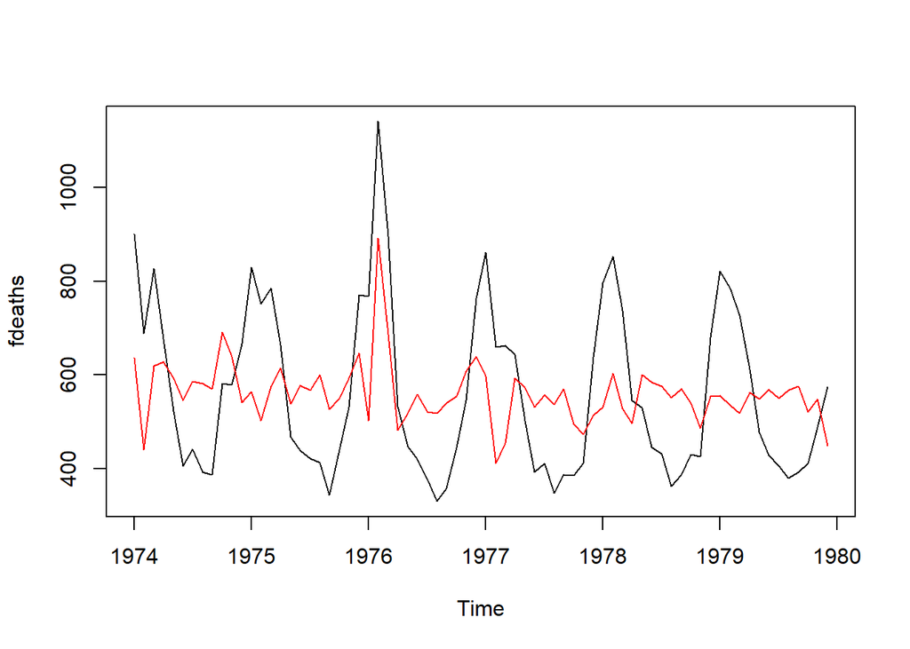

```r
plot(fdeaths)
lines(seasadj(stl_decomp), col="Red")
```

- The seasadj function adjusts the seasonality of the data and gives the data without the seasonal component.
- The above plotted graph shows the data without seasonal component which is in Red.

```r
f_stl <- forecast(stl_decomp,h=15)
f_stl
```

```
##          Point Forecast    Lo 80    Hi 80    Lo 95    Hi 95
## Jan 1980       808.9372 728.5757 889.2986 686.0349 931.8394
## Feb 1980       792.9875 712.4549 873.5202 669.8234 916.1516
## Mar 1980       752.3711 671.6675 833.0746 628.9456 875.7965
## Apr 1980       593.2966 512.4226 674.1707 469.6104 716.9828
## May 1980       473.0556 392.0114 554.0998 349.1092 597.0020
## Jun 1980       404.9165 323.7025 486.1306 280.7104 529.1227
## Jul 1980       398.2775 316.8940 479.6610 273.8122 522.7428
## Aug 1980       355.0664 273.5138 436.6191 230.3425 479.7904
## Sep 1980       360.3554 278.6340 442.0768 235.3733 485.3376
## Oct 1980       434.0708 352.1809 515.9606 308.8310 559.3105
## Nov 1980       482.1195 400.0615 564.1775 356.6226 607.6163
## Dec 1980       668.5819 586.3561 750.8076 542.8284 794.3353
## Jan 1981       808.9372 726.5440 891.3304 682.9276 934.9467
## Feb 1981       792.9875 710.4272 875.5479 666.7224 919.2527
## Mar 1981       752.3711 669.6439 835.0982 625.8508 878.8913
```

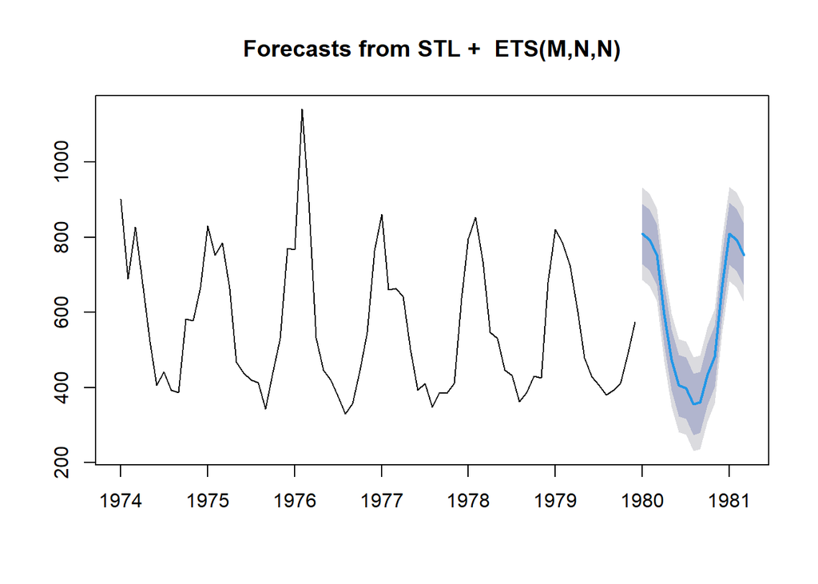

```r
plot(f_stl)
```

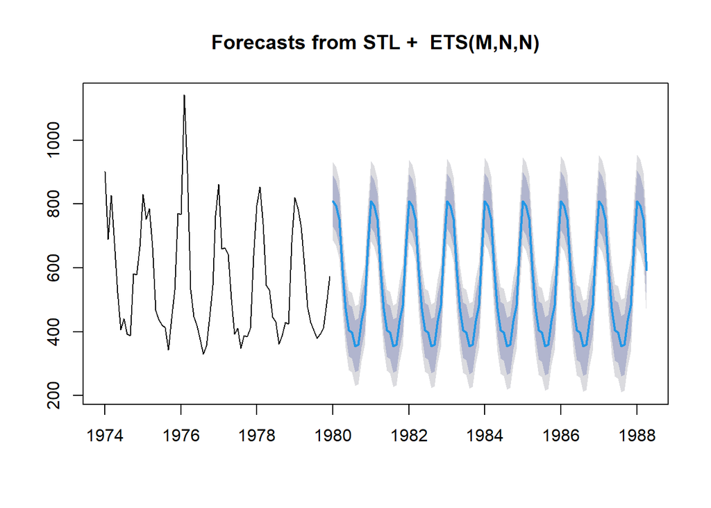

```r
f_stl2 <- forecast(stl_decomp,h=100)
plot(f_stl2)
```

* Here, the h is taken to be 100 to understand fucnction better. * This shows us that as time period of forecast increases, the confidence interval also increases. * Which means as the more time we forecast, the more worse our forecast is. Which makes sense.

## Another way of Decompose

```r
decomp_fdeaths <- decompose(fdeaths)

attributes(decomp_fdeaths)
```

```
## $names
## [1] "x"        "seasonal" "trend"    "random"   "figure"   "type"
##
## $class
## [1] "decomposed.ts"
```

```r
seasadj(decomp_fdeaths)
```

```
##           Jan      Feb      Mar      Apr      May      Jun      Jul      Aug
## 1974 647.6958 412.2792 626.8125 637.6375 595.0542 537.3292 589.3625 588.4958
## 1975 576.6958 475.2792 584.8125 624.6375 540.0542 569.3292 569.3625 607.4958
## 1976 513.6958 864.2792 695.8125 492.6375 520.0542 551.3292 524.3625 525.4958
## 1977 608.6958 383.2792 462.8125 603.6375 575.0542 523.3292 559.3625 543.4958
## 1978 542.6958 576.2792 536.8125 506.6375 603.0542 577.3292 579.3625 557.4958
## 1979 567.6958 508.2792 526.8125 572.6375 551.0542 560.3292 553.3625 574.4958
##           Sep      Oct      Nov      Dec
## 1974 579.2625 688.6875 641.9792 524.4042
## 1975 535.2625 546.6875 594.9792 629.4042
## 1976 549.2625 551.6875 609.9792 622.4042
## 1977 579.2625 491.6875 474.9792 496.4042
## 1978 579.2625 536.6875 488.9792 537.4042
## 1979 585.2625 517.6875 550.9792 432.4042
```

- decompose() function is one more way of using decompose.
- In the attribute we can see that there are trend, seasonal, and random variations.
- seasadj does the same job of adjusting the seasonal variation in the data.

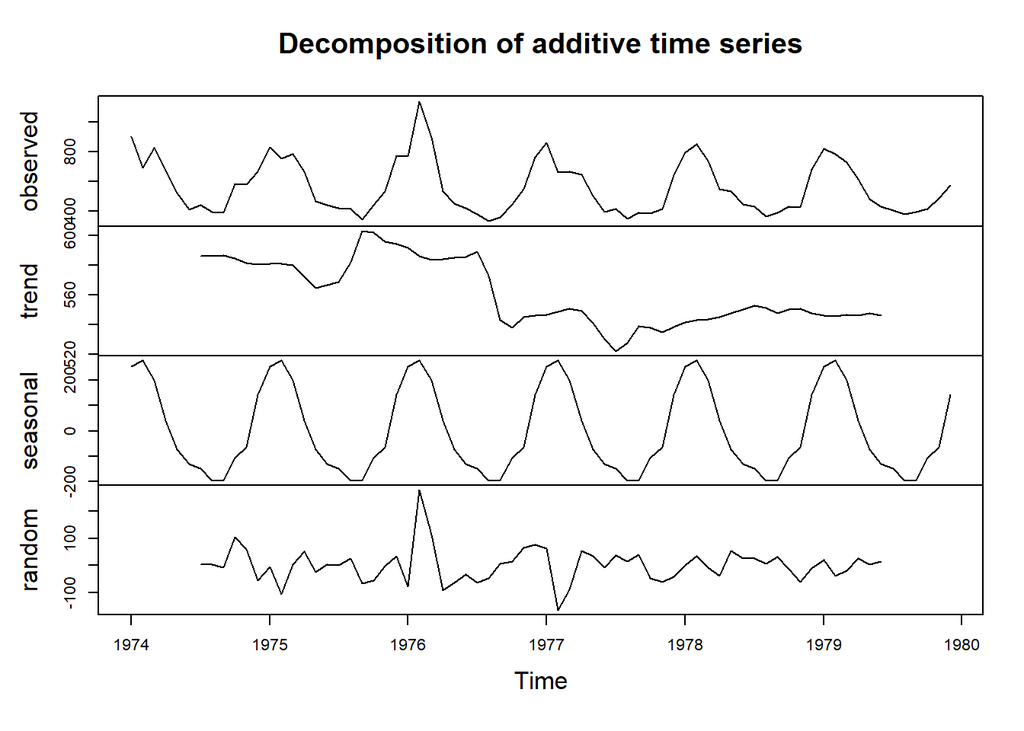

```r
plot(decomp_fdeaths)
```

- In the plot, it can be seen that the order of showing the trend, seasonal, and irregularity is different but the visuals are the same.
- “random” indicates the irregularity component and it is shown is a line graph for this function.